# Homeworksheet 3 – My answers

Jeffrey Walker

2023-09-22

# 5.3.2.1 part I

```r
set.seed(1) # so everyone gets the same result!
# R script to gain some intuition about standard deviation (sd) and standard error (se)
# you will probably need to install ggplot2 using library(ggplot2)
n <- 10000 # sample size
p <- 1000 # number of columns of fake data to generate

# this is a step-by-step method for constructing the matrix
N <- n * p # the total number of fake values to draw from a random distribution
fake_data <- rnorm(N, mean = 0, sd = 1) # create a vector of N fake values
fake_data <- matrix(fake_data, nrow = n, ncol = p) # put into a matrix object

# the three step-by-step lines above can be replaced
# with a more compact code using the pipe operator
fake_data <- rnorm(n * p, mean = 0, sd = 1) %>%
  matrix(nrow = n, ncol = p)

means <- apply(fake_data,2,mean) # the apply function is super useful
sds <- apply(fake_data,2,sd)
sems <- sds/sqrt(n)

1/sqrt(n)
```

```
## [1] 0.01
```

```r
sd(means)
```

```
## [1] 0.009713341
```

p = 100 [1] 0.4082483 [1] 0.4150002 difference = 0.0067519

The goal here is to show empirically that the a SEM *is* a standard deviation – it’s the an estimate of the expected standard deviation of a sample of means. Note this is better explored below 5.3.2.4 Part IV.

Questions

1. how close is sd(means) to the true SE?

The expected standard deviation of a sample of means (that is, the SEM) is 0.4082483

The measured standard deviation of our sample of means is 0.4150002

so, 0.4150002 - 0.4082483 = 0.0067519. This is pretty close! It’s 1.6% bigger than the expected value.

2. change p above to 1000. Now how close is sd(means) to the true SE?
3. change p above to 10,000. Now how close is sd(means) to the true SE?

p = 1000 [1] 0.4082483 [1] 0.4136838 difference = 0.0054355

p = 10000 [1] 0.4082483 [1] 0.4054534 difference = -0.0027949

What I’m addressing here is this – when we do a simulation experiment, how many reruns of the simulation should we run, that is, what value should we set p?. We can think about this qualitatively - if we only re-run the simulation a few times (like five) - then we might find atypical behavior since improbable things can happen with only a few flips of a coin. But if we re-run the simulation millions of times then we would expect to find something really close to the expected behavior. The problem is, running simulations many millions of times takes a long time. So, when we do a simulation experiment, we need some reasonable value for the number of simulations (p) that balances these two extremes.

So in general, we’d expect this difference (measured - true) to get smaller and smaller as p increases and when we use simulation to pump our intuition or actually study a problem, we want to make sure that we are using a value of p (number of runs of the simulation) that will give us the precision we need.

# 5.3.2.2 part II - means

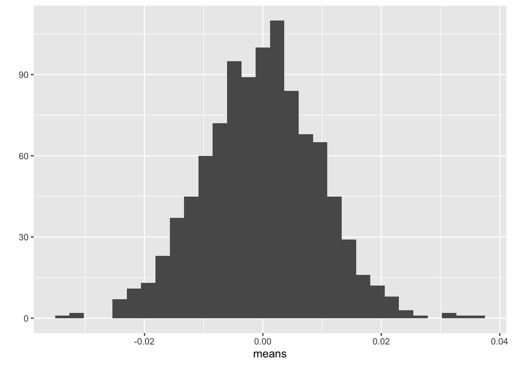

```r
qplot(means, bins = 30)
```

```r
mean(means)
```

```
## [1] -0.0003030714
```

```r
range(means)
```

```
## [1] -0.03281929  0.03735631
```

Questions

1. Remember that the true mean is zero. How close, in general, are the sampled means to the true mean. How variable are the means? How is this quantified?

Using n = 6 (with p = 1000)

- The mean of the 1000 means: -0.012
- The range of the 1000 means: -1.39 to 1.56
- The SD of the 1000 means: 0.414

The variability is measured by the range and the SD of the 1000 means, but the SD is a better measure because it has much more information in it about the whole distribution and not just the two extreme (minimum and maximum) value.

2. change n to 100, then replot. Are the means, in general, closer to the true mean? How variable are the means now?

Using n = 100 (with p = 1000)

- The mean of the 1000 means: 0.001
- The range of the 1000 means: -0.35 to 0.30
- The SD of the 1000 means: 0.101

Using n = 100, we sample fewer extreme (unlikely) events (samples with extreme means given the true mean) when we have a larger sample size. This is reflected in the SD (the variability) of the sampled means.

3. Is the mean estimated with n = 100 closer to the truth, in general, than the mean estimated with n = 6?

The sampling variability is less. That is, the mean of each sample is, in general, closer to the true mean.

4. Redo with n = 10000

n = 10000 (with p = 1000)

- The mean of the 1000 means: -0.00030
- The range of the 1000 means: -0.0328 to 0.0374
- The SD of the 1000 means: 0.0097

The sampling variability is much less. That is, the mean of each sample is, in general, **much** closer to the true mean.

# 5.3.2.3 part III - how do SD and SE change as sample size (n) increases?

```r
set.seed(1) # so everyone gets the same result!
# R script to gain some intuition about standard deviation (sd) and standard error (se)
# you will probably need to install ggplot2 using library(ggplot2)
n <- 10000 # sample size
p <- 1000 # number of columns of fake data to generate

# this is a step-by-step method for constructing the matrix
N <- n * p # the total number of fake values to draw from a random distribution
fake_data <- rnorm(N, mean = 0, sd = 1) # create a vector of N fake values
fake_data <- matrix(fake_data, nrow = n, ncol = p) # put into a matrix object

# the three step-by-step lines above can be replaced
# with a more compact code using the pipe operator
fake_data <- rnorm(n * p, mean = 0, sd = 1) %>%
  matrix(nrow = n, ncol = p)

sds <- apply(fake_data,2,sd)
sems <- sds/sqrt(n)

mean(sds)
```

```
## [1] 1.000012
```

```r
mean(sems)
```

```
## [1] 0.01000012
```

1. what is the mean of the standard deviations when n=6 (set p=1000)
- The mean of the 1000 SD: 0.9477648
- The mean of the 1000 SE: 0.3869233
2. what is the mean of the standard deviations when n=100 (set p=1000)
- The mean of the 1000 SD: 0.998564
- The mean of the 1000 SE: 0.0998564
3. when n = 1000? (set p=1000)
- The mean of the 1000 SD: 1.00041
- The mean of the 1000 SE: 0.03163574
4. when n = 10000? (set p=1000)
- The mean of the 1000 SD: 1.000012
- The mean of the 1000 SE: 0.01000012
5. how does the mean of the standard deviations change as n increases (does it get smaller? or stay about the same size)

The SE gets smaller as n increases. If n = infinity the SE will be zero (there is no error in the estimate of the mean because we’ve sampled everything!)

# 5.3.2.4 Part IV – Generating fake data with for-loops

Questions

What do sd(means) and mean(sems) converge to as n_sim is increased from 100 to 1000 to 10,000?

By converge I mean “as we move n_sim to infinity, the values of sd(mean) and mean(SEM) will get closer and closer to some number”.

These converge to the **expected SEM**, given the sample size n and the sample standard deviation $\sigma$.

What is the correct number?

1/sqrt(n)

We can plot this convergence, but here I use more values of n_sim to really see what I mean by “convergence”.

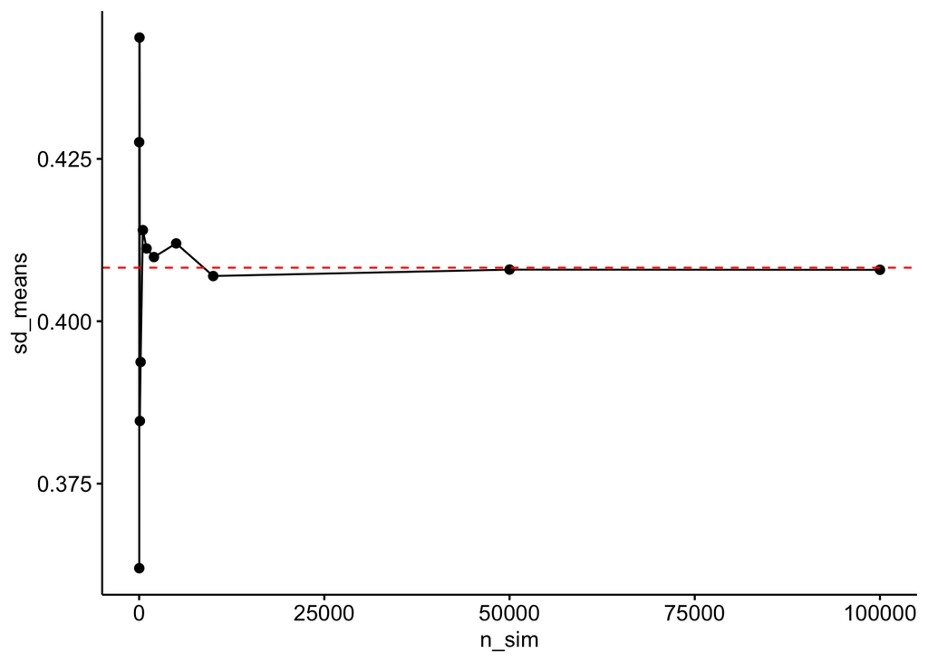

```r
#set.seed(1) # so everyone gets the same result!
# R script to gain some intuition about standard deviation (sd) and standard error (se)
# you will probably need to install ggplot2 using library(ggplot2)

n_sim_vec <- c(10, 20, 50, 100, 200, 500, 1000, 2000, 5000, 10000, 50000, 100000)
n <- 6
out_table <- data.table(
  n_sim = n_sim_vec,
  sd_means = as.numeric(NA),
  mean_sems = as.numeric(NA)
)
for(n_sim_i in 1:length(n_sim_vec)){
  n_sim <- n_sim_vec[n_sim_i]
  means <- numeric(n_sim_i)
  sds <- numeric(n_sim_i)
  sems <- numeric(n_sim_i)
  for(i in 1:n_sim){
    y <- rnorm(n, mean = 0, sd = 1)
    means[i] <- mean(y)
    sems[i] <- sd(y)/sqrt(n)
  }
  out_table[n_sim_i, sd_means := sd(means)]
  out_table[n_sim_i, mean_sems := mean(sems)]
}

# out_table %>%
#   kable() %>%
#   kable_styling()

gg1 <- ggscatter(data = out_table,
          x = "n_sim",
          y = "sd_means") +
  geom_line() +
  geom_hline(yintercept = 1/sqrt(n),
             linetype = "dashed",
             color = "red")
gg1
```

This convergence is easier to appreciate if we use a log base 10 scale for the x-axis.

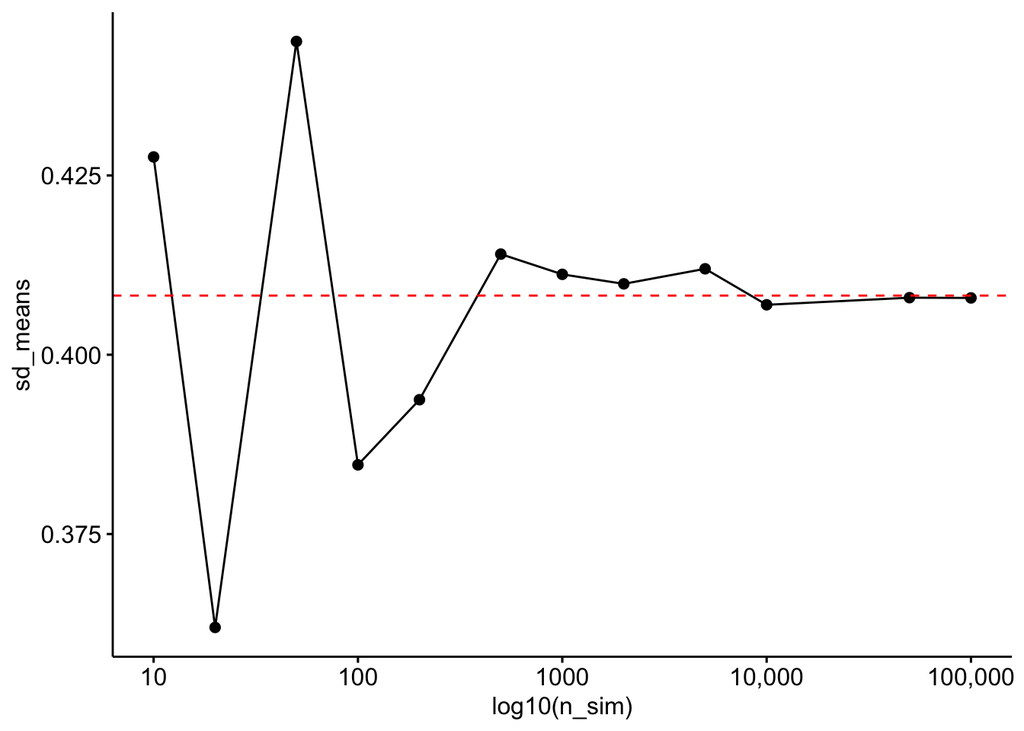

```r
gg1 +
  scale_x_continuous(trans='log10',
                     breaks = c(10, 100, 1000, 10000, 100000),
                     labels = c("10", "100", "1000", "10,000", "100,000")) +
  xlab("log10(n_sim)")
```

# 5.3.2.5 Part V – the sampling distribution of means is asymptotically Normal (wait, what?)

This is super important and why the assumption of normality is the least important of the big three: Normality, Homogeneity of variances, Independence